# CS 422 HW2

### Part 2.1.a.iv Plot a histogram of the residuals of the model. Does the histogram follow a Gaussian distribution? What can you say about the distribution of the residuals?

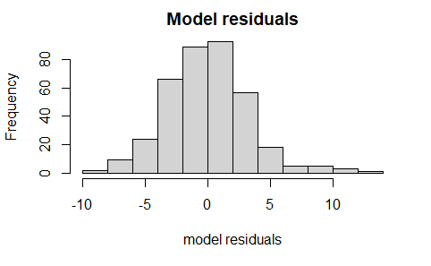

```r
#we plot a histogram of the residuals of the model
hist(model$residuals, main = "Model residuals", xlab = "model residuals")
```

The most statistically significant predictors are the ones with a lower p-value, and they are year, weight, origin and displacement. Intercept has also a low p-value (less than 0.001) but we don’t count it as a predictor. I will make a new model that only uses year, weight and origin as variables because they are the ones that have the lowest p-value.

```r
#we make the new model
model2 <- lm(mpg ~ ., data = subset(train.df, select = c(mpg,year,weight,origin) ))
```

### Part 2.1.b.ii Print the summary of the regression model created in (b)(i) and comment on how well the model fits the data by studying the R2 , RSE and RMSE. (Print out the values of R2 , RSE, and RMSE.)

```r
summary(model2)
```

```
Call:
lm(formula = mpg ~ ., data = subset(train.df, select = c(mpg,
    year, weight, origin)))

Residuals:
     Min       1Q   Median       3Q      Max
-10.0433  -2.1120  -0.0448   1.6867  13.2596

Coefficients:
              Estimate Std. Error t value Pr(>|t|)
(Intercept) -1.731e+01  4.123e+00  -4.197 3.39e-05 ***
year         7.448e-01  4.983e-02  14.946  < 2e-16 ***
weight      -5.973e-03  2.657e-04 -22.481  < 2e-16 ***
origin       1.223e+00  2.701e-01   4.525 8.15e-06 ***
---
Signif. codes:
0 ‘***’ 0.001 ‘**’ 0.01 ‘*’ 0.05 ‘.’ 0.1 ‘ ’ 1

Residual standard error: 3.389 on 368 degrees of freedom
Multiple R-squared:  0.8126,    Adjusted R-squared:  0.8111
F-statistic: 531.8 on 3 and 368 DF,  p-value: < 2.2e-16
```

```r
#we compute the values of RSS, RSE and RMSE
RSS2=sum((train.df$mpg - model2$fitted.values)**2)
RSE2=sqrt(RSS*(1/(nrow(train.df)-(ncol(subset(train.df, select = c(year,weight,origin))))-1)))
RMSE2=sqrt(RSS2/nrow(train.df))
DF2=(nrow(train.df)-(ncol(subset(train.df, select = c(year,weight,origin))))-1)

#We print the values asked
print(paste("R-sq value is",summary(model2)$r.squared))
```

```
[1] "R-sq value is 0.81258059379783"
```

```r
print(paste("Adjusted R-sq value is",summary(model2)$adj.r.squared))
```

```
[1] "Adjusted R-sq value is 0.811052718203791"
```

```r
print(paste("RSE value is",RSE2))
```

```
[1] "RSE value is 3.34856992629272"
```

```r
print(paste("RMSE value is",RMSE2))
```

```
[1] "RMSE value is 3.3708035382656"
```

### Part 2.1.b.iii Plot the residuals of the model.

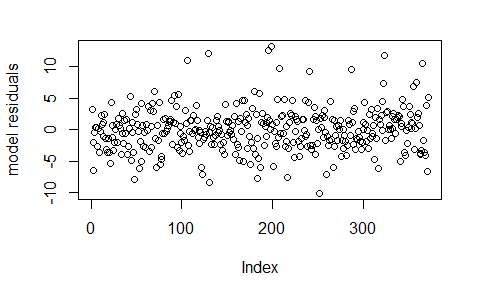

```r
#we plot the residuals of the model
plot(model2$residuals, ylab="model residuals" )
```